# Chapter 3. Logistic regression.

### Reading the data

This week I??m learning about logistic regression.

Before this analysis part I have been doing some data wrangling and prepared the data so that I am able to analyse it.

```r
#opening the data from the file and checking how it looks..

alc <- read.csv("~lottaimmeli/Documents/GitHub/IODS-project/Data/alc.csv", header = TRUE, sep = ",")
```

### About the data

This data is about student achievement in secondary education of two Portuguese schools. The data attributes include student grades, demographic, social and school related features and it was collected by using school reports and questionnaires. There were originally two datasets provided regarding the performance in two distinct subjects: Mathematics (mat) and Portuguese language (por).

In my data set I have combnined the information of these two datasets. I have observations of those 382 students who were present in both of the datasets Mathematics and Portuguese. In the original dataset there were 33 variables. However I have calculated some new variables ‘alc_use’ which corresponds to the average weekday and weekend alcohol consumption anb ‘high_use’ if the ‘alc_use’ is over 2.

You can find more information about the original data set and the variables here: https://archive.ics.uci.edu/ml/datasets/Student+Performance

```r
dim(alc)
```

```
## [1] 382  37
```

```r
colnames(alc)
```

```
##  [1] "school"      "sex"         "age"         "address"     "famsize"
##  [6] "Pstatus"     "Medu"        "Fedu"        "Mjob"        "Fjob"
## [11] "reason"      "nursery"     "internet"    "guardian"    "traveltime"
## [16] "studytime"   "failures"    "schoolsup"   "famsup"      "paid"
## [21] "activities"  "higher"      "romantic"    "famrel"      "freetime"
## [26] "goout"       "Dalc"        "Walc"        "health"      "absences"
## [31] "G1"          "G2"          "G3"          "alc_use"     "high_use"
## [36] "probability" "prediction"
```

```r
summary(alc)
```

```
##  school   sex          age        address famsize   Pstatus
##  GP:342   F:198   Min.   :15.00   R: 81   GT3:278   A: 38
##  MS: 40   M:184   1st Qu.:16.00   U:301   LE3:104   T:344
##                   Median :17.00
##                   Mean   :16.59
##                   3rd Qu.:17.00
##                   Max.   :22.00
##       Medu            Fedu             Mjob           Fjob
##  Min.   :0.000   Min.   :0.000   at_home : 53   at_home : 16
##  1st Qu.:2.000   1st Qu.:2.000   health  : 33   health  : 17
##  Median :3.000   Median :3.000   other   :138   other   :211
##  Mean   :2.806   Mean   :2.565   services: 96   services:107
##  3rd Qu.:4.000   3rd Qu.:4.000   teacher : 62   teacher : 31
##  Max.   :4.000   Max.   :4.000
##         reason    nursery   internet    guardian     traveltime
##  course    :140   no : 72   no : 58   father: 91   Min.   :1.000
##  home      :110   yes:310   yes:324   mother:275   1st Qu.:1.000
##  other     : 34                       other : 16   Median :1.000
##  reputation: 98                                    Mean   :1.448
##                                                    3rd Qu.:2.000
##                                                    Max.   :4.000
##    studytime        failures      schoolsup famsup     paid     activities
##  Min.   :1.000   Min.   :0.0000   no :331   no :144   no :205   no :181
##  1st Qu.:1.000   1st Qu.:0.0000   yes: 51   yes:238   yes:177   yes:201
##  Median :2.000   Median :0.0000
##  Mean   :2.037   Mean   :0.2016
##  3rd Qu.:2.000   3rd Qu.:0.0000
##  Max.   :4.000   Max.   :3.0000
##  higher    romantic      famrel         freetime        goout
##  no : 18   no :261   Min.   :1.000   Min.   :1.00   Min.   :1.000
##  yes:364   yes:121   1st Qu.:4.000   1st Qu.:3.00   1st Qu.:2.000
##                      Median :4.000   Median :3.00   Median :3.000
##                      Mean   :3.937   Mean   :3.22   Mean   :3.113
##                      3rd Qu.:5.000   3rd Qu.:4.00   3rd Qu.:4.000
##                      Max.   :5.000   Max.   :5.00   Max.   :5.000
##       Dalc            Walc           health         absences
##  Min.   :1.000   Min.   :1.000   Min.   :1.000   Min.   : 0.0
##  1st Qu.:1.000   1st Qu.:1.000   1st Qu.:3.000   1st Qu.: 1.0
##  Median :1.000   Median :2.000   Median :4.000   Median : 3.0
##  Mean   :1.482   Mean   :2.296   Mean   :3.573   Mean   : 4.5
##  3rd Qu.:2.000   3rd Qu.:3.000   3rd Qu.:5.000   3rd Qu.: 6.0
##  Max.   :5.000   Max.   :5.000   Max.   :5.000   Max.   :45.0
##        G1              G2              G3           alc_use
##  Min.   : 2.00   Min.   : 4.00   Min.   : 0.00   Min.   :1.000
##  1st Qu.:10.00   1st Qu.:10.00   1st Qu.:10.00   1st Qu.:1.000
##  Median :12.00   Median :12.00   Median :12.00   Median :1.500
##  Mean   :11.49   Mean   :11.47   Mean   :11.46   Mean   :1.889
##  3rd Qu.:14.00   3rd Qu.:14.00   3rd Qu.:14.00   3rd Qu.:2.500
##  Max.   :18.00   Max.   :18.00   Max.   :18.00   Max.   :5.000
##   high_use        probability     prediction
##  Mode :logical   Min.   :0.2883   Mode :logical
##  FALSE:268       1st Qu.:0.3597   FALSE:272
##  TRUE :114       Median :0.4170   TRUE :110
##                  Mean   :0.4555
##                  3rd Qu.:0.5197
##                  Max.   :0.9398
```

### Choosing the variables to study the relationship between high or low alcohol consumption.

The purpose of my analysis is to study the relationships between high/low alcohol consumption and some of the other variables in the data. To do this, I choose 4 interesting variables (failure, absences, famrel and higher) and state the hypotheses.

1. The first variable “failure” tells about the number of past class failures. I think there might be a correlation between higher alcohol consumption and more class failures.
2. “Absences” corresponds to the number of school absences. I am instrested to find out if those who drink more have more school absences.
3. “Famrel” corresponds to the quality of family relationships. Maybe those who have poor family relationships consume more alcohol?
4. “Higher” clarifies if these students want to have higher education (yes or no). Maybe those who want to educate them selves in the future will study more and drink less..

### Numerically and graphically exploring the distributions of my chosen variables and their relationships with alcohol consumption.

1. **First, is there some relationship between alcohol comsumptions and number of past class failures.**

```r
#Numerically exploring the relationship between high_use and failure. table and geom_count plot

mytable <- table(high_use = alc$high_use, number_of_past_class_failures = alc$failures)

addmargins(mytable)
```

```
##         number_of_past_class_failures
## high_use   0   1   2   3 Sum
##    FALSE 244  12  10   2 268
##    TRUE   90  12   9   3 114
##    Sum   334  24  19   5 382
```

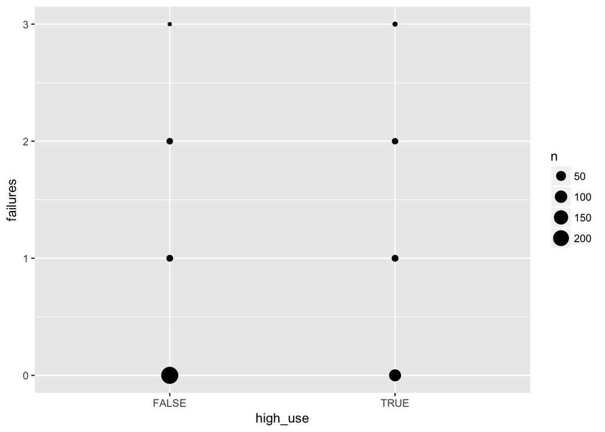

```r
library(ggplot2)

failure1 <- ggplot(alc, aes(x=high_use, y = failures))
failure1 + geom_count()
```

In this table and plot I can see that the ones who have low use of alcohol might proportionally have less class failures compared to the students with high alcohol. As seen here the ones who consume less alcohol more often have no past class failures.

2. **Is there some relationship between alcohol consumption and school absences?**

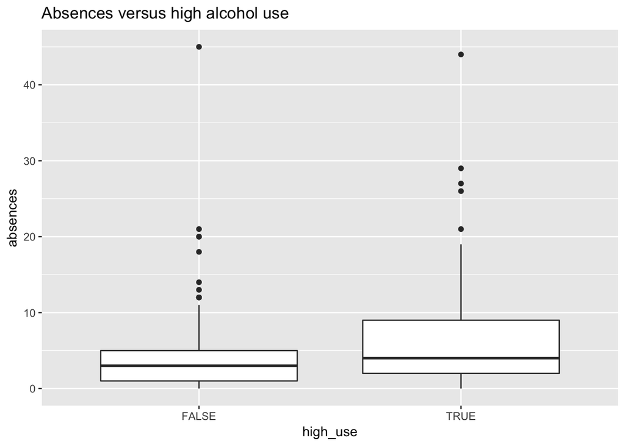

```r
#making a boxplot
g <-ggplot(alc, aes(x=high_use, y = absences))

g2 <- g + geom_boxplot() + ggtitle("Absences versus high alcohol use")
g2
```

It looks like there might be a correlation between high use of alcohol and more school absences.

3. **How about the relationship between alcohol consumption and family relationships?**

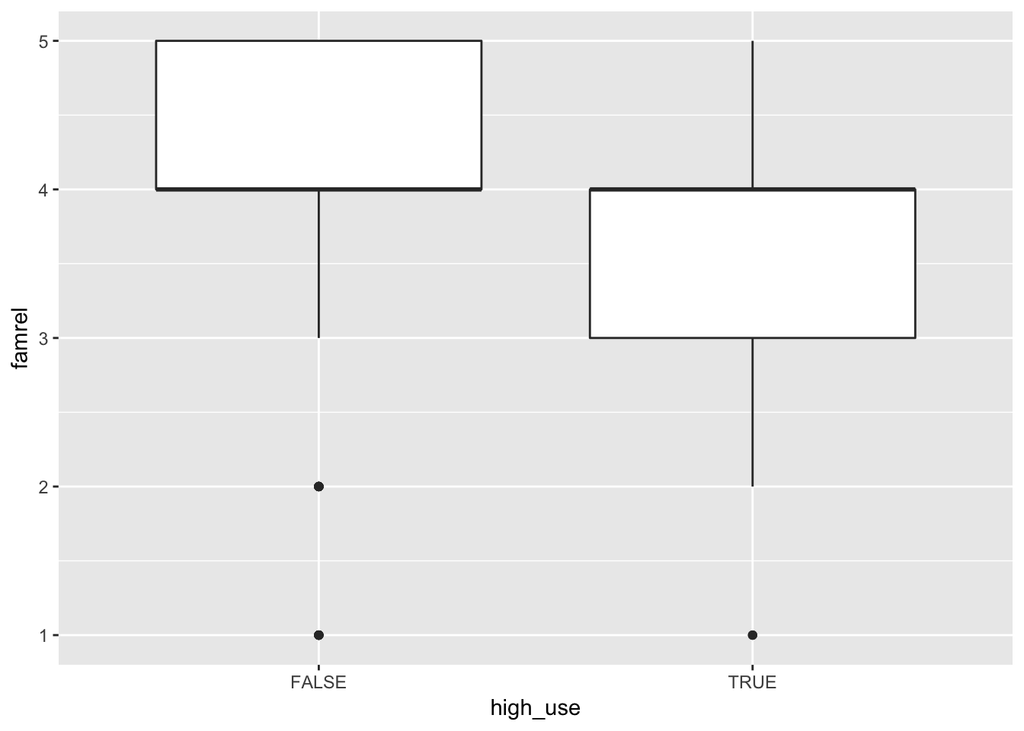

```r
#making a boxplot

g_fam <-ggplot(alc, aes(x=high_use, y = famrel,))

g_fam2 <- g_fam + geom_boxplot()
g_fam2
```

It seems that those who have low use of alcohol think that their family relationships are better (higher points). But which one is the cause and which one the effect. Are the students having bad relationships at home and they start to use more alcohol. Or is everything going well at home and from the point they start to use more alcohol the relationships at home gets more problematic.

4. **Relationship between alcohol consumption and future educational plans**

```r
table_plans <- table(high_use= alc$high_use, wants_high_education = alc$higher)
table_plans
```

```
##         wants_high_education
## high_use  no yes
##    FALSE   9 259
##    TRUE    9 105
```

```r
round(prop.table(table_plans) * 100, 1)
```

```
##         wants_high_education
## high_use   no  yes
##    FALSE  2.4 67.8
##    TRUE   2.4 27.5
```

Maybe it seems that those who consume more alcohol, do not have that often plan to get high education..

### Logistic regression

Now I want statistically explore the relationship between my four chosen variables and the binary high/low alcohol consumption variable as the target variable. Here is the summary of my fitted model.

```r
#find the model with glm in the first model there is the intercept and in the m2 I took the intercept away

m <- glm(high_use ~ failures + absences + famrel + higher, data = alc, family = "binomial")
summary(m)
```

```
##
## Call:
## glm(formula = high_use ~ failures + absences + famrel + higher,
##     family = "binomial", data = alc)
##
## Deviance Residuals:
##     Min       1Q   Median       3Q      Max
## -2.3593  -0.7890  -0.6902   1.1782   1.8993
##
## Coefficients:
##             Estimate Std. Error z value Pr(>|z|)
## (Intercept) -0.12562    0.74528  -0.169 0.866143
## failures     0.43484    0.19618   2.217 0.026653 *
## absences     0.08341    0.02272   3.671 0.000241 ***
## famrel      -0.22708    0.12502  -1.816 0.069322 .
## higheryes   -0.36274    0.55177  -0.657 0.510924
## ---
## Signif. codes:  0 '***' 0.001 '**' 0.01 '*' 0.05 '.' 0.1 ' ' 1
##
## (Dispersion parameter for binomial family taken to be 1)
##
##     Null deviance: 465.68  on 381  degrees of freedom
## Residual deviance: 436.43  on 377  degrees of freedom
## AIC: 446.43
##
## Number of Fisher Scoring iterations: 4
```

```r
coef(m)
```

```
## (Intercept)    failures    absences      famrel   higheryes
## -0.12562333  0.43483926  0.08340567 -0.22707832 -0.36273561
```

```r
m2 <- glm(high_use ~ failures + absences + famrel + higher - 1, data = alc, family = "binomial")
summary(m2)
```

```
##
## Call:
## glm(formula = high_use ~ failures + absences + famrel + higher -
##     1, family = "binomial", data = alc)
##
## Deviance Residuals:
##     Min       1Q   Median       3Q      Max
## -2.3593  -0.7890  -0.6902   1.1782   1.8993
##
## Coefficients:
##           Estimate Std. Error z value Pr(>|z|)
## failures   0.43484    0.19618   2.217 0.026653 *
## absences   0.08341    0.02272   3.671 0.000241 ***
## famrel    -0.22708    0.12502  -1.816 0.069322 .
## higherno  -0.12562    0.74528  -0.169 0.866143
## higheryes -0.48836    0.51592  -0.947 0.343857
## ---
## Signif. codes:  0 '***' 0.001 '**' 0.01 '*' 0.05 '.' 0.1 ' ' 1
##
## (Dispersion parameter for binomial family taken to be 1)
##
##     Null deviance: 529.56  on 382  degrees of freedom
## Residual deviance: 436.43  on 377  degrees of freedom
## AIC: 446.43
##
## Number of Fisher Scoring iterations: 4
```

```r
coef(m2)
```

```
##    failures    absences      famrel    higherno   higheryes
##  0.43483926  0.08340567 -0.22707832 -0.12562333 -0.48835893
```

The future education plan (plans to get a higher education) have also negative effect on the high alcohol use (-0.4), but it is not statistically significant.

**Presenting and interpreting the coefficients of the model as odds ratios and provide confidence intervals for them.**

```r
library(tidyverse)
library(dplyr)

#compute odds ratios and and confidence intervals
OR <- coef(m) %>% exp
CI <- exp(confint(m))
cbind(OR, CI)
```

```
##                    OR     2.5 %   97.5 %
## (Intercept) 0.8819470 0.1995909 3.776889
## failures    1.5447147 1.0499664 2.282173
## absences    1.0869827 1.0418018 1.139025
## famrel      0.7968584 0.6230747 1.019051
## higheryes   0.6957704 0.2372414 2.121797
```

In this table one can see the coefficients of the model as odds ratios and their confidence intervals. The odds ratios for failures is 1.54 (CI 1.05-2.28) and for absences 1.08 (1.04-1.14) meaning that higher consumption of alcohol increases the odds for absence and failures by 1.54 and 1.08 times respectively. The better family relationship makes the odds for high alcohol consumption 0.8 times less likely.

The higher educational plan is not significant since the coefficient is 0.70 and CI is 0.2-2.1 (number 1 in included in the CI).

### Exploring the predictive power of my model.

```r
# predict the probability of high use and then adding, the new variable in the alc dataset. Then using the probability to make a prediction of high_use. lookin the last 10 observations

probabilities <- predict(m, type= "response")
alc <- mutate(alc, probability = probabilities)
alc <- mutate(alc, prediction = probability > 0.5)
select(alc, failures, absences, famrel, high_use, probability, prediction) %>% tail(10)
```

```
##     failures absences famrel high_use probability prediction
## 373        1        0      4    FALSE   0.2765114      FALSE
## 374        1        7      5     TRUE   0.3531843      FALSE
## 375        0        1      5    FALSE   0.1764851      FALSE
## 376        0        6      4    FALSE   0.2898242      FALSE
## 377        1        2      5    FALSE   0.2646186      FALSE
## 378        0        2      4    FALSE   0.2262058      FALSE
## 379        2        2      2    FALSE   0.5234763       TRUE
## 380        0        3      1    FALSE   0.3857482      FALSE
## 381        0        4      2     TRUE   0.3523118      FALSE
## 382        0        2      4     TRUE   0.2262058      FALSE
```

```r
table(high_use = alc$high_use, prediction = alc$prediction) %>% prop.table %>% addmargins
```

```
##         prediction
## high_use      FALSE       TRUE        Sum
##    FALSE 0.65445026 0.04712042 0.70157068
##    TRUE  0.25392670 0.04450262 0.29842932
##    Sum   0.90837696 0.09162304 1.00000000
```

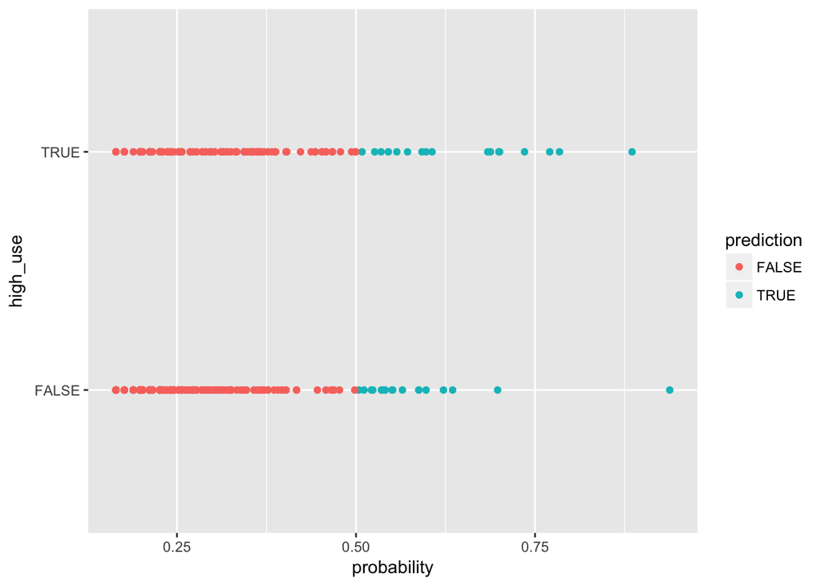

```r
gpred <- ggplot(alc, aes(x = probability, y = high_use, col = prediction))

gpred + geom_point()
```

```r
# the training error

# define a loss function (mean prediction error)
loss_func <- function(class, prob) {
  n_wrong <- abs(class - prob) >0.5
  mean(n_wrong)
}
```

The proportion of incorrectly classified observations (meaning the training error) is (0.30) 30%. I think the percentage is pretty high. I can??t really think my model is very good when one third of the observations are incorrectly classified.

Then I also made a 10-fold cross-validation where I got the same number (0.30) 30% as the average number of wrong predictions.

```r
loss_func(class = alc$high_use, prob = alc$probability)
```

```
## [1] 0.3010471
```

```r
# K-fold cross-validation
library(boot)
cv <- cv.glm(data = alc, cost = loss_func, glmfit = m, K = 10)

# average number of wrong predictions in the cross validation
cv$delta[1]
```

```
## [1] 0.3089005
```